# Morality in the time of cognitive famine - General supplementary

Jonas Kristoffer Lindeløv

December, 2018

The following analyses are not necessarily bound to one particular experiment, and are not simple extensions of analyses in the main manuscript.

```r
library(dplyr)
library(lme4)
```

```r
library(ggplot2)
source("misc/functions inference.R")
```

## A validity check: Equation correctness and reaction time

(see the notebook on PGG for this) An important part of the complex span task is that subjects engage in the processing task, thereby preventing chunking- or rehearsal strategies. We provided a monetary incentive to do the processing task correctly.

Still, it is possible that some subjects would prioritize it lower in order to improve recall, and such behavior would undermine the purpose of using a complex span task, making it more like a simple forward letter span task.

We considered what indices would reveal such behavior. A priori, it is hard to distinguish between poor math skills and laziness. Similarly, it is difficult to distinguish between being a low-span subject or just not investing an effort to encode the items.

However, short reaction times in combination with low accuracy would be one such index: poor performance and no effort (time) to improve it. We show the data for the equation tasks descriptively below using violin plots with 25% and 75% quartiles as well as (horizontally) jittered data.

Across tasks (PGG and Dots) and span levels (1-7), for all correctness levels where there is a considerable amount of data, the reaction times are highly similar. Only for correctness levels with very little data do we observe deviations from this, likely due to noise. We conclude that, to the best of our knowledge, the task was succesful in engaging subjects in processing.

FIrst, let’s load the PGG data in here:

```r
# Load the PGG (not in csv because the matrix columns would be lost)
D_pgg = readRDS('data/pgg.Rda')
D_pgg = subset(D_pgg, condition=='experiment')  # Remove practice, etc.
D_pgg = select(D_pgg, -encode, -equationCorrect, -equationScores, -equationRTs, -recallAns, -equationAnss)  # Tidyr doesn't like these matrix columns and we won't be using them
D_pgg = droplevels(D_pgg)

# Load Dots
D_dots = readRDS('data/dots.Rda')
D_dots = droplevels(subset(D_dots, condition == 'experiment'))  # Not practice, etc
D_dots = select(D_dots, -encode, -equationCorrect, -equationScores, -equationRTs, -recallAns, -equationAnss)  # Tidyr doesn't like these matrix columns and
D_dots = droplevels(D_dots)

# And merge together:
D_all = plyr::rbind.fill(D_dots, D_pgg)  # All together now!
D_all$task = ifelse(D_all$exp_part %in% c("pgg_concurrent","pgg_cumulative"), yes='PGG', no='Dots')
```

Now, for the actual analysis:

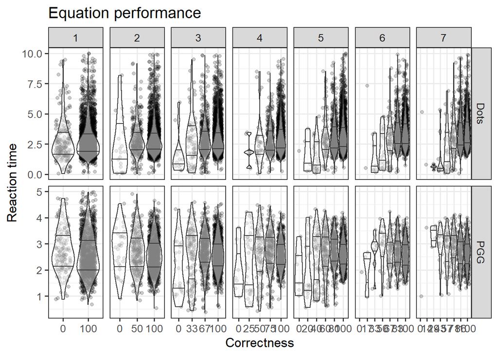

```r
fit = lmer(dotsRT ~ level + stimType + (1|id), subset(D_all, exp_part=="dots_cumulative"))

#D.plot = subset(D_all,
ggplot(subset(D_all, equationRT < 10), aes(x=factor(round(equationCorrectness*100)), y=equationRT)) +
  #stat_summary(fun.data=mean_cl_boot) +
  geom_jitter(width=0.3, height=0, alpha=0.2) +   # Only jitter width
  geom_violin(draw_quantiles = c(0.25, 0.75), alpha=0.5, scale='width') +
  facet_grid(task~span, scales='free') +
  #coord_cartesian(ylim=c(0, 7)) +
  labs(x='Correctness', y='Reaction time', title='Equation performance') +
  #scale_x_continuous(breaks= scales::pretty_breaks()) +
  theme_bw(13)
```

```r
# TODO: Methods: RT for PGG
#fit = lmer(pggRT ~ level + stimType + (1|id), subset(D, exp_part=="pgg_cumulative"))
```

If one wants to look at performance anyway (equations and recall), we can do that. First plot it:

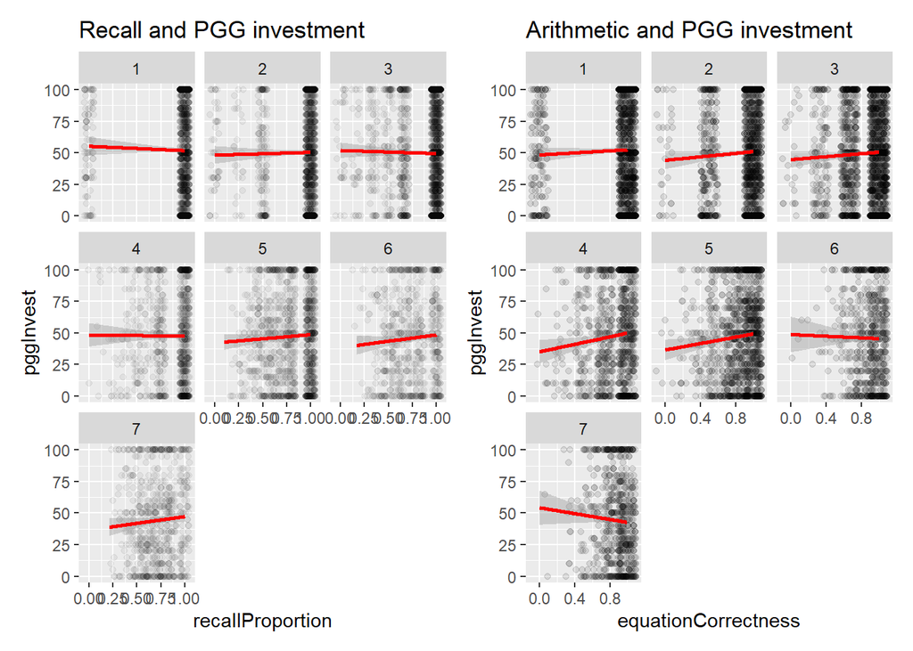

```r
# Recall
tradeoff_recall = ggplot(D_pgg, aes(x=recallProportion, y=pggInvest)) +
  #geom_density2d() +
  geom_jitter(width=0.05, height=0, alpha=0.05) +
  geom_smooth(color='red', method=lm) +
  facet_wrap(~span, ncol=3) +
  labs(title='Recall and PGG investment')

# Equations
tradeoff_equation = ggplot(D_pgg, aes(x=equationCorrectness, y=pggInvest)) +
  #geom_density2d() +
  geom_jitter(width=0.1, height=0, alpha=0.1) +
  geom_smooth(color='red', method=lm) +
  facet_wrap(~span, ncol=3) +
  labs(title='Arithmetic and PGG investment')

# All together now
library(patchwork)
tradeoff_recall + tradeoff_equation
```

Then inferentially:

```r
LRT(D_pgg,
    pggInvest ~ recallProportion  + equationCorrectness + stimType + time_hours + (span|id),
    pggInvest ~                                         + stimType + time_hours + (span|id))
```

```
## Data: D
## Models:
## fit.null: pggInvest ~ +stimType + time_hours + (span | id)
## fit.full: pggInvest ~ recallProportion + equationCorrectness + stimType +
## fit.full:     time_hours + (span | id)
##          npar   AIC   BIC logLik deviance  Chisq Df Pr(>Chisq)
## fit.null    7 78719 78769 -39353    78705
## fit.full    9 78676 78740 -39329    78658 46.904  2   6.53e-11 ***
## ---
## Signif. codes:  0 '***' 0.001 '**' 0.01 '*' 0.05 '.' 0.1 ' ' 1
##                        Estimate Std. Error    t value
## (Intercept)          38.9897386   2.651256 14.7061404
## recallProportion      4.8234534   1.327098  3.6345864
## equationCorrectness   6.4234344   1.178009  5.4527894
## stimTypeLetters       0.8488141   3.676512  0.2308749
## time_hours          -15.1400412   2.614251 -5.7913494
##                                      2.5 %     97.5 %
## (Intercept)          38.9897386  33.793373  44.186104
## recallProportion      4.8234534   2.222389   7.424518
## equationCorrectness   6.4234344   4.114579   8.732289
## stimTypeLetters       0.8488141  -6.357016   8.054644
## time_hours          -15.1400412 -20.263879 -10.016203
## [1] "BIC-based Bayes Factor: 1781628.4"
```

… and for the dots task:

```r
LRT_binom(D_dots,
          dotsCorrect ~ recallProportion + equationCorrectness + dotsIncentive + dotsN + stimType + (time_hours|id),
          dotsCorrect ~                                      1 + dotsIncentive + dotsN + stimType + (time_hours|id))
```

```
## Data: D
## Models:
## fit.null: dotsCorrect ~ 1 + dotsIncentive + dotsN + stimType + (time_hours |
## fit.null:     id)
## fit.full: dotsCorrect ~ recallProportion + equationCorrectness + dotsIncentive +
## fit.full:     dotsN + stimType + (time_hours | id)
##          npar   AIC   BIC  logLik deviance  Chisq Df Pr(>Chisq)
## fit.null    7 18075 18130 -9030.3    18061
## fit.full    9 18074 18144 -9027.9    18056 4.8723  2     0.0875 .
## ---
## Signif. codes:  0 '***' 0.001 '**' 0.01 '*' 0.05 '.' 0.1 ' ' 1
##                         Estimate Std. Error      z value      Pr(>|z|)
## (Intercept)          8.210625425 0.23106287  35.53416155 1.459496e-276
## recallProportion    -0.139519336 0.07764113  -1.79697721  7.233924e-02
## equationCorrectness  0.181872520 0.12313250   1.47704719  1.396630e-01
## dotsIncentivecheat  -2.011372983 0.05672626 -35.45752860 2.220678e-275
## dotsN               -0.461973279 0.01234848 -37.41135919 2.554001e-306
## stimTypeLetters     -0.005207303 0.13325368  -0.03907812  9.688281e-01
##                                         2.5 %       97.5 %
## (Intercept)         3679.8432128 2339.6357119 5787.7583257
## recallProportion       0.8697762    0.7469977    1.0127349
## equationCorrectness    1.1994613    0.9422706    1.5268515
## dotsIncentivecheat     0.1338048    0.1197254    0.1495400
## dotsN                  0.6300392    0.6149737    0.6454738
## stimTypeLetters        0.9948062    0.7661481    1.2917077
## [1] "BIC-based Bayes Factor: 1621.4*"
```

## Percieved load (questionnaire data)

Mostly for exploratory reasons, we did ask subjects how they perceived the task with respect to frustration, stress, effort, difficulty, and satisfaction. Here, we explore whether subjects “felt” the difference in load.

Again we see very small correspondences when considering the range-6 scale, but a large degree of the probability density is towards positive values.

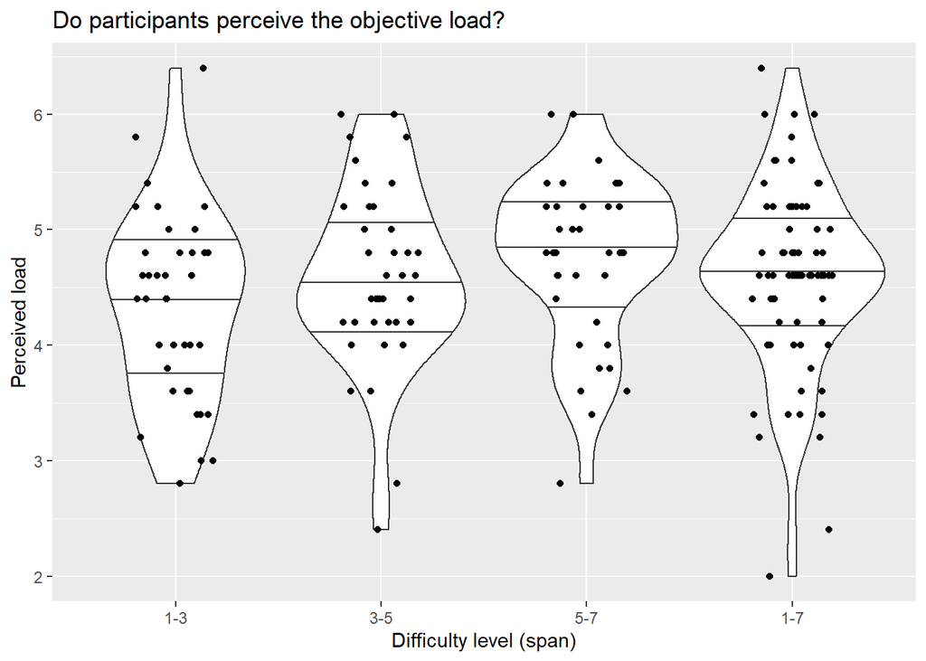

```r
perceived_load_cols = c('qStress', 'qDifficulty', 'qFrustration', 'qEffort', 'qSatisfied')

# Summarise per subject
D_id_dots = D_dots %>%
  mutate(qSatisfied = 1 + (7 - qSatisfied),  # Same direction as other questions
         perceived_load = rowMeans(select(D_dots, perceived_load_cols))) %>%  # Mean of load ratings
  group_by(id, level) %>%
  filter(dotsReceiver=='Self' & dotsIncentive == 'cheat') %>%
  summarise(dotsCorrect = mean(dotsCorrect, na.rm=T),
            perceived_load = mean(perceived_load))

# Plot the relationship
ggplot(D_id_dots, aes(x=level, y=perceived_load)) +
  geom_violin(draw_quantiles = c(0.25, 0.5, 0.75)) +
  geom_jitter(width=0.2, height=0) +
  labs(x = 'Difficulty level (span)', y='Perceived load', title='Do participants perceive the objective load?')
```

Test it inferentially:

```r
library(brms)
D.analyse.dots = filter(D_id_dots, level !='1-7' & !is.na(perceived_load))  # ... and no NA data
result_level_dots = brm(perceived_load ~ level, D.analyse.dots)  # Quick: just run with the defaults
```

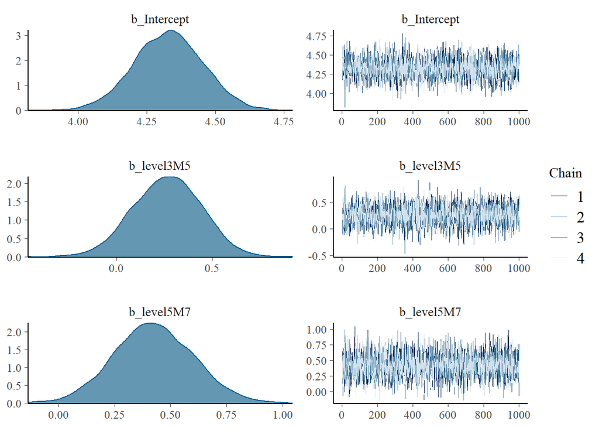

```r
plot(result_level_dots, pars='^b_')
```

… and now for degree of cheating:

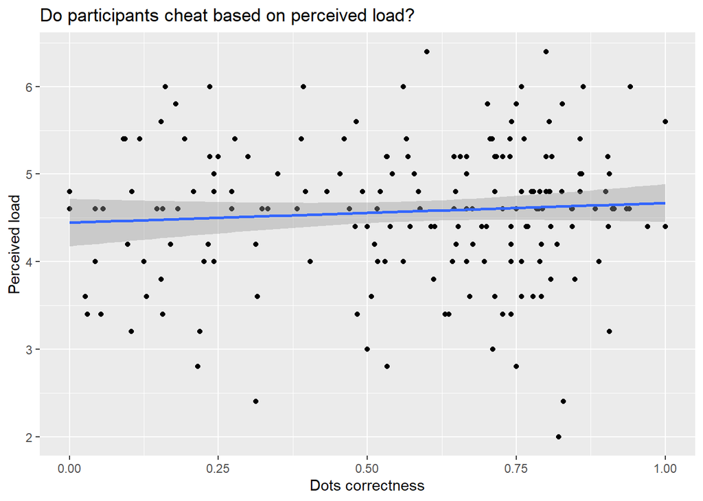

```r
# Plot it
ggplot(D_id_dots, aes(x=dotsCorrect, y=perceived_load)) +
  geom_point() +
  geom_smooth(method='lm') +
  labs(x='Dots correctness', y='Perceived load', title='Do participants cheat based on perceived load?')
```

Test it inferentially:

```r
# Inferentially
result_cheat_dots = brm(perceived_load ~ dotsCorrect, D.analyse.dots)  # Simple linear regression
```

```
## recompiling to avoid crashing R session
```

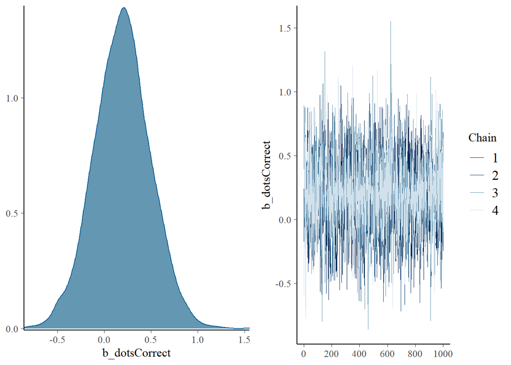

```r
plot(result_cheat_dots, pars='b_dotsCorrect')
```

## Load and accuracy

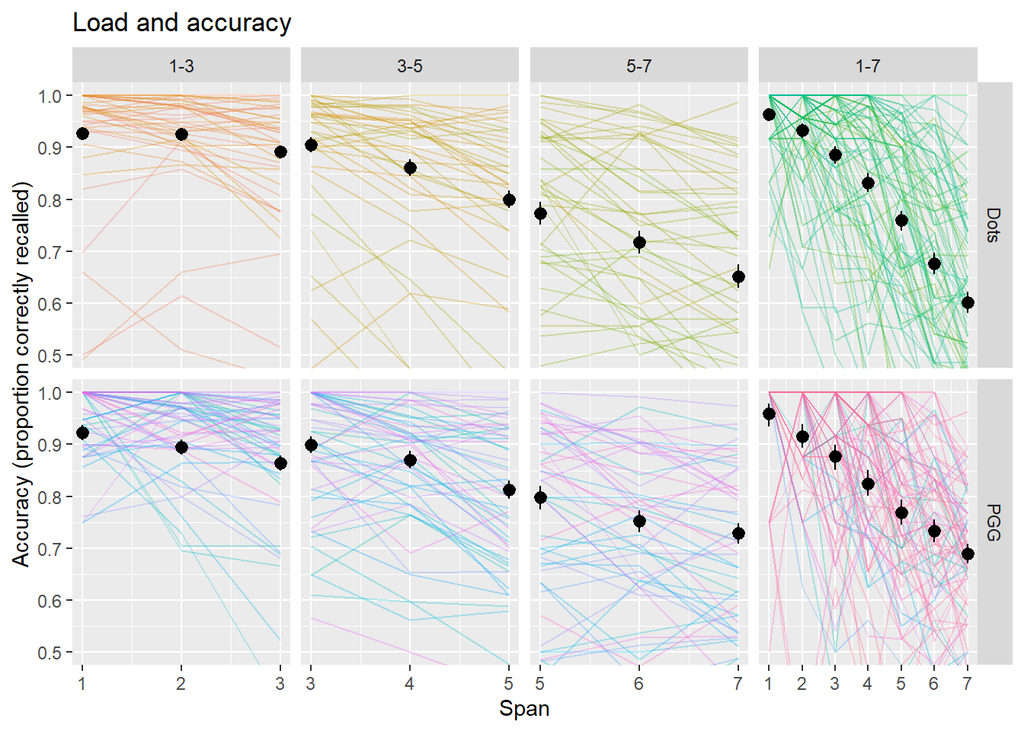

```r
ggplot(D_all, aes(x = span, y = recallProportion)) +
  # Individual participants
  stat_summary(aes(color = id), fun.y = mean, geom = "line", alpha = 0.3) +

  # Average
  stat_summary(fun.data = mean_cl_boot, geom = "pointrange", lwd = 0.5) +

  # Layout and theming
  facet_grid(task~level, scales = "free_x") +
  coord_cartesian(ylim = c(0.5, 1)) +
  scale_x_continuous(breaks = c(1:7)) +
  theme(legend.position = "none") +  # Do not show legend for participants
  labs(y = "Accuracy (proportion correctly recalled)", x = "Span", title = "Load and accuracy")
```

```r
ggsave("figures/Figure S13 - Load and accuracy.png", width = 6, height = 4)
```

```r
# Get one row per participant per question answer
D_q = D_all %>%
  group_by(id) %>%
  summarise(
    qFrustration = mean(qFrustration),
    qStress = mean(qStress),
    qDifficulty = mean(qDifficulty),
    qEffort = mean(qEffort),
    task = head(task, 1),
    level = head(level, 1)
  ) %>%
  tidyr::pivot_longer(c("qFrustration", "qStress", "qDifficulty", "qEffort"))
```

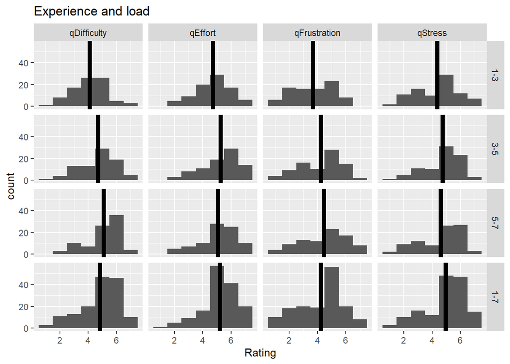

```r
# Compute means for geom_vline (to make it respect faceting)
D_q_means = D_q %>%
  group_by(level, name) %>%
  summarise(value = mean(value, na.rm = T))
# Finally plot it
ggplot(D_q, aes(x = value)) +
  geom_histogram(bins = 7) +
  geom_vline(aes(xintercept = value), data = D_q_means, size = 2) +
  facet_grid(level~name) +
  labs(x = "Rating", title = "Experience and load")
```

```r
ggsave("figures/Figure S14 - Load and experience.png", width = 6, height = 4)
```

## High and low performers

An improvement on the analysis above would be to code “load” not as the absolute span length of the trial, but rather the *difference* between the trial’s span length and the individual’s working memory capacity. Below, we provide code that does this.

```r
D_PGG = filter(D_all, level == "1-7", task == "PGG")

library(mcp)
model = list(
  recallLocation | trials(span) ~ 1,
  1 + (1|id) ~ 0 + span
)
```

```r
model_str = "
model {

  # Priors for population-level effects
  cp_0 = MINX  # mcp helper value.
  cp_2 = MAXX  # mcp helper value.

  cp_1 ~ dunif(MINX, MAXX)
  cp_1_sd ~ dnorm(0, 1/((MAXX-MINX)/2)^2) T(0, )
  int_1 ~ dunif(0.7, 1)
  span_2 ~ dunif(-0.5, 0)

  # Priors for varying effects
  for (id_ in 1:n_unique_id) {
    cp_1_id_uncentered[id_] ~ dnorm(0, 1/(cp_1_sd)^2) T(MINX - cp_1, MAXX - cp_1)
  }
  cp_1_id = cp_1_id_uncentered - mean(cp_1_id_uncentered)  # vectorized zero-centering


  # Model and likelihood
  for (i_ in 1:length(span)) {
    X_1_[i_] = min(span[i_], (cp_1 + cp_1_id[id[i_]]))
    X_2_[i_] = min(span[i_], cp_2) - (cp_1 + cp_1_id[id[i_]])

    # Fitted value
    y_[i_] =

      # Segment 1: recallLocation | trials(span) ~ 1
      (span[i_] >= cp_0) * int_1 +

      # Segment 2: recallLocation | trials(span) ~ 1 + (1 | id) ~ 0 + span
      (span[i_] >= (cp_1 + cp_1_id[id[i_]])) * span_2 * X_2_[i_]

    # Likelihood and log-density for family = binomial()
    recallLocation[i_] ~ dbin(y_[i_], span[i_])
    loglik_[i_] = logdensity.bin(recallLocation[i_], y_[i_], span[i_])
  }
}"

fit_str = mcp(model, data = D_PGG, family = binomial(), cores = 5, chains = 5, adapt = 500, iter = 1000, jags_code = model_str)
```

```
## Parallel sampling in progress...
```

```
## Finished sampling in 166.5 seconds
```

Graphically:

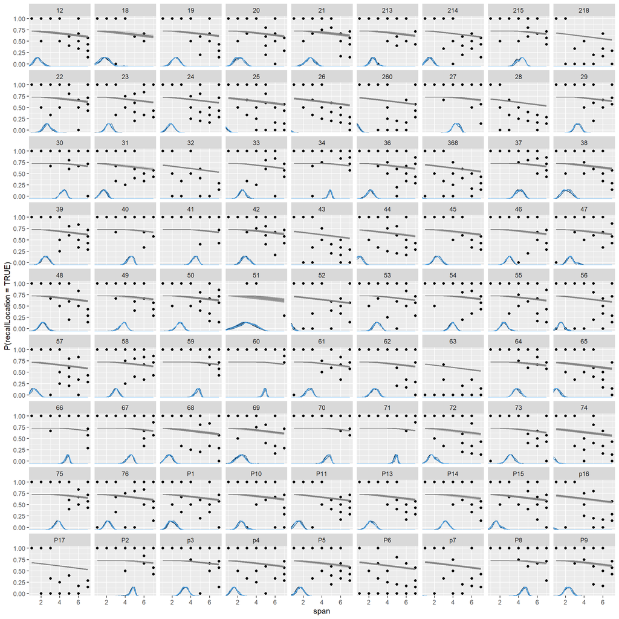

```r
plot(fit_str, facet_by = "id")
```

Numerically (in descending order of estimated participant span):

```r
library(dplyr)
mcp:::tidy_samples(fit_str, varying = TRUE, population = FALSE, absolute = TRUE) %>%
  group_by(id) %>%
  summarise(
    mean = mean(cp_1_id),
    lower = quantile(cp_1_id, 0.025),
    upper = quantile(cp_1_id, 0.975)
  ) %>%
  arrange(desc(mean))
```

```
## # A tibble: 81 x 4
##    id     mean lower upper
##    <fct> <dbl> <dbl> <dbl>
##  1 71     4.87  4.40  5.20
##  2 60     4.86  4.39  5.20
##  3 34     4.83  4.36  5.17
##  4 66     4.79  4.24  5.17
##  5 P2     4.73  3.96  5.14
##  6 59     4.67  3.99  5.12
##  7 70     4.60  3.92  5.08
##  8 P8     4.55  3.76  5.09
##  9 40     4.52  3.79  5.04
## 10 67     4.50  3.80  5.03
## # ... with 71 more rows
```